# Assignment 1

Federico Manenti 790032

# 1) The decision Tree

Analizzando il caso proposto, la rappresentazione tramite albero decisionale può risolvere il primo problema. Nella struttura dell’albero ho deciso di non utilizzare un costo fisso, ma di vedere il profitto netto come payoff finale.

```r
tree_1 = yaml.load_file(paste0(path, "tree_1.yaml"))

result_1 = dtree(yl = tree_1)
plot(result_1, final = F)
```

[interactive chart not shown]

# 2) Expected value

Supponendo MC utilizzi come criterio di scelta l’Expected Value (EV), si può trovare la decisione che prenderebbe:

```r
plot(result_1, final = T)
```

[interactive chart not shown]

In questo caso, come si può vedere dal percorso sottolineato, a MC converrebbe produrre tutte le $200000$ schede subito.

# 3) Utility Function and Certainty Equivalent

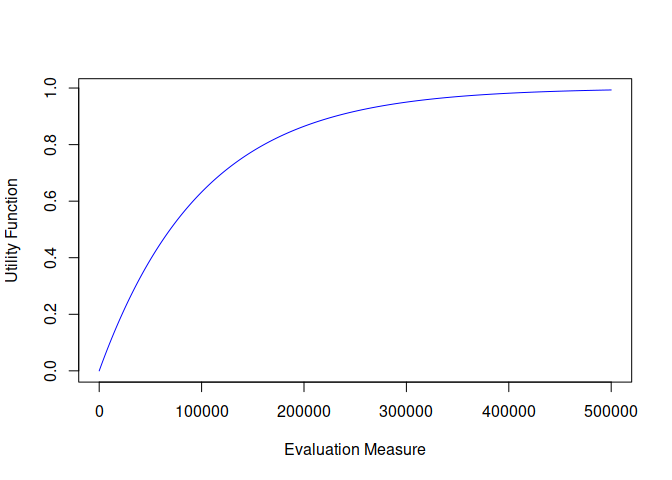

```r
utilityFunction = function(X, R) {
  u = 1- exp(-X/R)
  return(u)
}

x = seq(from = 0, to = 500000)
R = 100000
plot(x, utilityFunction(x, R), type="l", col="blue",
     ylab="Utility Function", xlab="Evaluation Measure")
```

Per comodità salvo i profitti netti in un vettore e poi calcolo l’utility per i quattro valori.

```r
profit = c(350000, -150000, 100000, 50000)
U = c()

for (i in c(1:4)) {
  U[i] = utilityFunction(profit[i], R)

}
```

```
## [1]  0.9698026 -3.4816891  0.6321206  0.3934693
```

Ora si possono calcolare le utility per i due $Chance$ $Nodes$.

```r
U_1 = (U[1]+U[2])*0.5
U_2 = (U[3]+U[4])*0.5
```

| Rami | Utility |
| --- | --- |
| Ramo 1 | -1.2559432 |
| Ramo 2 | 0.5127949 |

Un albero decisionale aiuta a visualizare anche qui la situazione:

[interactive chart not shown]

Per calcolare la $Certainty$ $Equivalent$ utilizziamo la formula $CE = -R*ln(1-E[U])$ applicandola ai valori ottenuti con la funzione di utilità.

```r
CEquivalent = function(U, R){
  CE = -R*ln(1-U)
  return(CE)
}
```

Le CE associate ai due rami sono:

| Rami | Certain Equivalent |
| --- | --- |
| Ramo 1 | -81356.82 |
| Ramo 2 | 71907.02 |

Come si può osservare dai valori della $Certainty$ $Equivalent$ (e $Utility$) in questo caso la MC sceglierebbe il percorso opposto rispetto al punto 1). Ossia costruire $100000$ schede subito e aspettare la scelta di DISCO per produrre o meno le altre.

# 4) Modification of the process

L’azienda MC manufacturing ha la possibilità di sviluppare una nuova tecnologia, investendo 25000$ in ricerca e sviluppo, che se avesse successo (probabilità del 40%) farebbe diminuire il costo di produzione di una run da 250000$ a 50000$. Mentre, se fallisse, i costi di produzione rimarrebbero invariati. Un’ulteriore complicazione però sta nel fatto che la R&D non è immediata e quindi non può influenzare la prima run di produzione, ma abbatterebbe i costi solo alla seconda nel caso DISCO decida di esercitare l’opzione di acquisto. Quindi MC deve decidere subito se investire o meno. Per chiarire meglio la situazione usiamo un ulteriore albero decisionale:

```r
tree_3 = yaml.load_file(paste0(path, "tree_3.yaml"))

result_3 = dtree(yl = tree_3)
plot(result_3, final = T)
```

[interactive chart not shown]

In questo caso quindi MC procederebbe come nel primo caso: cosruirebbe tutte le 200000 schede subito. Questa scelta è data dal fatto che la R&D non è immediata, ma influenzerebbe solo una seconda run di produzione.

# 5) Value of Information

Supponiamo ora che MC manufacturing possa pagare un esperto per ottenere con certezza l’informazione relativa al successo o meno della R&D. Con il seguente albero decisionale possiamo deteminare il massimo che MC sarà disposta a pagare per l’informazione.

```r
tree_4 = yaml.load_file(paste0(path,"tree_4.yaml"))

result_4 = dtree(yl = tree_4)
plot(result_4, final = T)
```

[interactive chart not shown]

Il secondo ramo prende in considerazione il fatto che la R&D non vada a buon fine e quindi MC procederebbe fabbricando tutte le 200000 schede subito perchè, come precedentemente dimostrato, in questo caso è la soluzione più profiqua. Per determinare quanto MC sia disposta a pagare per ottenere l’informazione perfetta sull’esito dell’investimento si sottrarre il profitto atteso appena ottenuto (120000$) e quello maggiore ottenuto negli atri casi (100000$) ossia quando le schede sono prodotte tutte subito. L’azienda MC manufacturing è disposta quindi a pagare un massimo di 20000$ per ottenere l’informazione perfetta.